# R Notebook

```r
library(tidyverse)
data("msleep")
```

H0: the mean sleep time of all animals in the sample is the same as the sleep time of the jabberwokie

H1: there is a difference in the sleep time of the mean sleep time of all animals in the sample and the sleep of the jabberwockie

```r
obs_stat <- sleep_times %>%
  summarise(mean(sleep_total)) %>%
  pull()
```

```r
null_distribution <- sleep_times %>%
  specify(response = sleep_total) %>%
  hypothesize(null = "point", mu = 7) %>%
  generate(reps = 1000, type = "bootstrap") %>%
  calculate(stat = "mean")

null_distribution
```

```
Response: sleep_total (numeric)
Null Hypothesis: point
```

| replicate | stat |
| --- | --- |
| 1 | 7.378313 |
| 2 | 6.853012 |
| 3 | 6.733735 |
| 4 | 7.043373 |
| 5 | 7.986747 |
| 6 | 6.967470 |
| 7 | 7.704819 |
| 8 | 6.598795 |
| 9 | 6.848193 |
| 10 | 7.185542 |

[output cut: 990 more lines]

```r
null_distribution %>%
  visualise() +
  shade_p_value(obs_stat = obs_stat, direction = "both")
```

[output not shown]

```r
null_distribution %>%
  get_p_value(obs_stat = obs_stat, direction = "both")
```

| p_value |
| --- |
| 0 |

H0: omnivores have the same mean sleep time or lower than herbivores

```
µo ≤ µh
```

H1: omnivores have a longer mean sleep time than herbivores

```
µo > µh
```

```r
vore <- msleep %>%
  filter(vore == "herbi"|vore == "omni") %>%
  select(vore, sleep_total)
```

```r
null_distribution_vore
```

```
Response: sleep_total (numeric)
Explanatory: vore (factor)
Null Hypothesis: independence
```

| replicate | stat |
| --- | --- |
| 1 | 0.326875 |
| 2 | 0.245625 |
| 3 | -0.347500 |
| 4 | 0.253750 |
| 5 | -2.565625 |
| 6 | 1.277500 |
| 7 | 0.611250 |
| 8 | 0.733125 |
| 9 | -0.428750 |
| 10 | -0.095625 |

[output cut: 990 more lines]

```r
obs_diff_in_mean <- vore %>%
  filter(vore == "omni") %>%
  summarise(mean(sleep_total)) -
  vore %>%
  filter(vore == "herbi") %>%
  summarise(mean(sleep_total)) %>%
  pull()
```

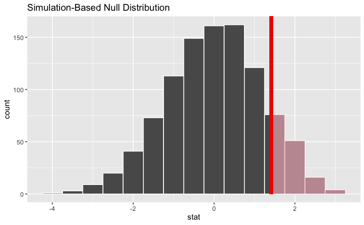

```r
null_distribution_vore %>%
  visualise() +
  shade_p_value(obs_stat = obs_diff_in_mean, direction = "right")
```

| p_value |
| --- |
| 0.118 |

at the 95% significance level there is not enough evidence to reject the null hypothesis, that there is no significant difference between the mean sleep times of herbivores and omnivores

H0: is the proportion of domesticated animals compared to all animals in the sample is lower than or equal to 0.05

```
prop(domestic) ≤ 0.05
```

H0: is the proportion of domesticated animals compared to all animals in the sample is greater than 0.05

```
prop(domestic) > 0.05
```

assuming NAs are not domesticated as they would be well documented, so FALSE

```r
  sum(is_domestic$is_domestic)/nrow(is_domestic)
```

```
[1] 0.1204819
```

```r
null_prop <- is_domestic %>%
  specify(response = is_domestic, success = "TRUE") %>%
  hypothesize(null = "point", p = 0.05) %>%
  generate(reps = 5000, type = "draw") %>%
  calculate(stat = "prop")

head(null_prop)
```

```
Response: is_domestic (factor)
Null Hypothesis: point
```

| replicate | stat |
| --- | --- |
| 1 | 0.09638554 |
| 2 | 0.02409639 |
| 3 | 0.06024096 |
| 4 | 0.04819277 |
| 5 | 0.06024096 |
| 6 | 0.06024096 |

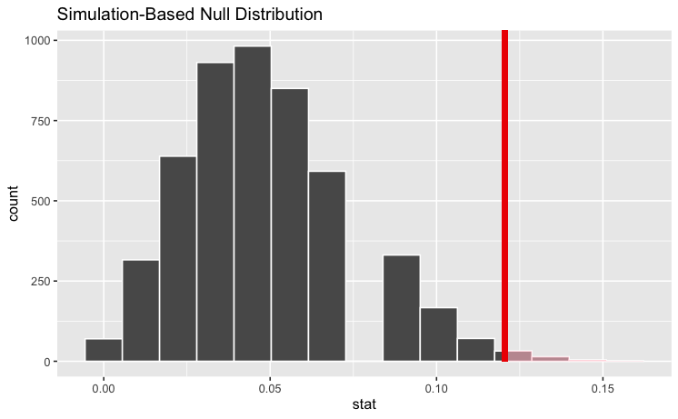

| p_value |
| --- |
| 0.0102 |

There is evidence to suggest at the 98.97% confidence level that we can reject the null hypothesis that the proportion of domesticated animals compared to all animals in the sample is lower than or equal to 0.05.

1.2

1. type of test: point estimate test of proportion

H0: 40% or fewer people in the town have heard of the coffee shop

```
π ≤ 0.4
```

H1: more than 40% of people in the town have heard of the coffee shop

```
π > 0.4
```

2. type of test: independent two-sample test

H0: the placement of the website banner at the top of the page does not affect, or negatively affects the CTR

```
π top ≤ π else
```

H1: the banner being placed at the top of the page yields a higher CTR than the alternative banner placement

```
π top > π else
```

3. type of test: paired two-sample test

H0: there is no difference in the widths of parts from the start and end of the week

```
µ start = µ end
```

H1: there is a difference in the widths of parts from the start and end of the week

```
µ start ≠ µ end
```

1.3

1. at the 95% confidence level there is not evidence to suggest that more than 40% of the town has heard of the coffee shop
2. at the 99% confidence level there is enough evidence to reject the null hypothesis, that there is no difference or negative difference in CTR when the banner is at the top of the webpage
3. at the 95% confidence level there is nowhere near enough evidence to suggest a difference in widths of the parts manufactured at the start of the week compared to the end of the week